# 1_R_data_cleaning

Hari Sankar Nayak

2024-03-20

# Setting the working directory

```r
getwd()
```

```
## [1] "/Users/antonurfels/My Drive/programs/data-works/training-materials/code"
```

```r
#setwd("C:/Users/hsn28/Downloads/All_postdoc/Rice_yield_gap_all/dataverse_files_2017r")
#setwd("C:/Users/hsn28/Desktop/R_training")
library(readxl)
```

# Reading the data

```r
survey <- read.csv("../data/CSISA_IND_LDS_Rice_2017_Data.csv")
#Import using GUI.

survey_market = read.csv("../data/Market_data.csv")
survey_market = read.csv("../data/Market_data.csv",skip = 1)
```

# Remove duplicate rows

```r
#calculate number of rows from each data frame
nrow(survey)
```

```
## [1] 6857
```

```r
nrow(survey_market)
```

```
## [1] 6857
```

```r
#calculate number of UNIQUE IDs
length(unique(survey_market$meta.instanceID))
```

```
## [1] 6831
```

```r
length(unique(survey$meta.instanceID))
```

```
## [1] 6831
```

```r
library(tidyverse)
library(dplyr)
dmost <- survey %>% distinct(meta.instanceID, .keep_all = TRUE)
dmarket <- survey_market %>% distinct(meta.instanceID, .keep_all = TRUE)
### Note distinct comes from dplyr package, there are other functions which can do the same thing.
```

# Lets merge both data frames

```r
merged_data <- merge(dmost, dmarket, by.x = "meta.instanceID", by.y = "meta.instanceID")
head(merged_data)
```

```
##                             meta.instanceID collectionDate surveyConsent
## 1 uuid:00040f48-2dc9-4146-83b3-e9faa21556f8      29-Aug-18           yes
## 2 uuid:000d3ccf-a7ab-491a-bf11-f760641c818a      29-Aug-18           yes
## 3 uuid:000e692f-5275-4b5d-857d-69f81200827b      05-Sep-18           yes
## 4 uuid:00212b88-a094-4710-9cfa-fe3d90491e98      26-Sep-18           yes
## 5 uuid:002239ad-0edd-406e-99f7-0bee42628546      05-Jun-18           yes
## 6 uuid:0034b8fe-2f0e-47e2-be1a-c491022510bf      27-Sep-18           yes
##   A.q101_country A.q102_state A.q103_district A.q104_subDistrict A.q105_village
## 1          India UttarPradesh         Gazipur            Gazipur        Mahepur
## 2          India        Bihar      Samastipur          Kalyanpur    Virsinghpur
## 3          India        Bihar      Samastipur        Sarairanjan Rupauli Buzurg
## 4          India UttarPradesh       Gorakhpur          Chargawan  Parmeshwarpur
## 5          India        Bihar           Patna          Naubatpur   Dumri, Bihta
## 6          India        Bihar           Buxar          Nawanagar          Waina
##   A.q110_fName A.q111_fGender     A.q112_fEdu A.q113_aadharNum
```

[output cut: 517 more lines]

# Lets have simple variable names

Here, we want to make sure our life is easy - and that future users can more readily work with the data. Also, variable names are crucial for automation. If you always use the same variable names - then you can recycle your scripts for analysis. You will see that later.

So we strive for simple, meaningful and short names. Most importantly - be consistent. I like to use underscores for variable_names (called ‘snake case’). Some people like capitals for variableNames (called ‘camel case’). Try to be clean and simple.

Here are some good examples:

- yield; n_rate; production_plot; production_farm; irrigation_number

Here are some bad examples:

- 12013_YTH; YTHLP; NP2024;

Sometimes surveys collect a lot of data as researchers might want to explore very specific topics. At the same time - we collect more and more data and want to ensure that the common and most important variables are always collected and managed the same way. Then we can easily merged them in the future and use in united analysis. So when starting, try to stay focused and priortize the most important ones first.The most important variables for agronomic surveys are normally:

General ones:

- Location: Administrative units at level 0(country), 2(province/state),3(district),4(village,municipality)
- GPS Coordinates ideally of each plot; sometimes it is of household: latitude, longitude
- Landholding info: plot number, area of total farm, area of largest plot
- Household info: number of people; sex of household head; age of household head; education;
- Cultivation options: crop; season; previous crop;

Then for the production practices, you can think chronologically from planting to harvest and key aspect like fertilizer, irrigation, weeds, pests, disease,:

- Planting: planting date; seed rate; variety; crop establishment method (e.g. DSR, TPR); seedling age; etc.
- Fertilizer: use of farm yard manure; fertilizer type; basal application amount; top dressing amounts;
- Irrigation: number of irrigations; number of drainages; irrigation source; pump use; energy source;
- Weed/Pest/Disease: most common weeds; number of weeding times; number of spraying;
- Harvest: harvest date; harvest method; production amount plot; production amount whole farm; price received; percentage sold to market;

Importantly! Do not calculate variables at this step. Just focus on making the existing variables manageable.

At the next step we will then calculate key variables. Commonly calculated variables include:

- Yield (t per ha); N rate (kg per ha); revenue (USD per ha); duration (days);

For each calculated variable it is best to have it’s own section. Sometimes it happens that we make a mistake in the calculations - it is then easy to adjust this.

Tasks: Take a look at these scripts. What do they do?

1. Can you make your life easier by further improving the variable names?
2. Focus on just a few that you are interested in.

```r
#Rename a single column
names(merged_data)[names(merged_data) == "C-q305_cropLargestArea"] <- 'cropLargestArea'
#Rename with consisten Pattern

#j=strsplit(colnames(merged_data), "_")
#df <-data.frame(t(as.data.frame.list(j)))
#names(merged_data) = df$X2

#cor_names = names(merged_data)
#cor_names
#write.csv(cor_names,"cor_names.csv")
#write.csv(names(merged_data), "old_names.csv")
names = read.csv("../data/cor_names.csv")
names(merged_data) <- names$new

which(duplicated(names(merged_data)))
```

```
## [1] 227 244
```

```r
merged_data[,which(duplicated(names(merged_data)))] = NULL
which(duplicated(names(merged_data)))
```

```
## integer(0)
```

# Structure of data, coverting to other type

When we read data, R tries to detect the type. But sometimes this does not work perfectly. Normally this is the case when there are mixed data types. Or when NA (not available) values are not coded consistently. Or when there’s just a type.

Ideally, we should constrain our data types during data collection - so that numeric can only enter numbers. Text can only choose from drop down. But mistakes, happen. And we need to adjust these here.

```r
str(merged_data)
```

```
## 'data.frame':    6831 obs. of  242 variables:
##  $ meta.instanceID        : chr  "uuid:00040f48-2dc9-4146-83b3-e9faa21556f8" "uuid:000d3ccf-a7ab-491a-bf11-f760641c818a" "uuid:000e692f-5275-4b5d-857d-69f81200827b" "uuid:00212b88-a094-4710-9cfa-fe3d90491e98" ...
##  $ collectionDate         : chr  "29-Aug-18" "29-Aug-18" "05-Sep-18" "26-Sep-18" ...
##  $ surveyConsent          : chr  "yes" "yes" "yes" "yes" ...
##  $ country                : chr  "India" "India" "India" "India" ...
##  $ state                  : chr  "UttarPradesh" "Bihar" "Bihar" "UttarPradesh" ...
##  $ district               : chr  "Gazipur" "Samastipur" "Samastipur" "Gorakhpur" ...
##  $ subDistrict            : chr  "Gazipur" "Kalyanpur" "Sarairanjan" "Chargawan" ...
##  $ village                : chr  "Mahepur" "Virsinghpur" "Rupauli Buzurg" "Parmeshwarpur" ...
##  $ fName                  : chr  "xxxxx" "xxxxx" "xxxxx" "xxxxx" ...
##  $ fGender                : chr  "male" "male" "male" "male" ...
##  $ fEdu                   : chr  "seniorSecondary" "noSchooling" "noSchooling" "matriculation" ...
##  $ aadharNum              : chr  "xxxx" "xxxx" "xxxx" "xxxx" ...
##  $ socialCategory         : chr  "OBC" "OBC" "OBC" "General" ...
##  $ mobile                 : chr  "xxxx" "xxxx" "xxxx" "xxxx" ...
```

[output cut: 86 more lines]

```r
class(merged_data)
```

```
## [1] "data.frame"
```

```r
merged_data$cropSeedAmt <- as.numeric(merged_data$cropSeedAmt)
merged_data$basalDAP    <- as.numeric(merged_data$basalDAP)
merged_data$basalUrea   <- as.numeric(merged_data$basalUrea)
merged_data[,c("varName","droughtSeverity")] = sapply(merged_data[,c("varName","droughtSeverity")], as.factor)
```

# Variety name

Now that we have a rather clean dataset, let’s explore some of the variables. Let’s start with varieties. With varieties, we often find many names that apply for the same variety. Also, often data collectors enter varieties with typos. So it’s important to spend some time here and use our knowledge to adjust these. Please do not edit the data directly in excel. But you can use R scripts to replace or correct misspellings. This ensures full integrity so that anyone can later see what you did with the dataset and perhaps identify ways to improve it.

We can start by getting an overview of all the variety names using the table functions. We need to then work through these one by one to ensure they are all correct and we don’t have misspellings.

```r
table(merged_data$varName)
```

```
##
##                   Aditya                   Aghani                    Ankur
##                        1                       10                        9
##                Arize6129                Arize6444            Arize6444Gold
##                        9                        2                     1062
##                  Basmati         BhagalpurKatarni               Binadhan10
##                       18                        5                        3
##               Binadhan11                  Binayak                  BL 4341
##                       82                        1                        3
##                  BPT5204                     BR11               BRRIDhan33
##                      455                        2                        1
##                   Chintu                Dhanya775               Dhaulagiri
##                       33                       56                        5
##                  Diamond                 Gangotri                   Garima
##                        7                        8                        3
##                   Gautam           Golden_MTU7029           Gorakhnath-509
##                       10                        5                       31
##                     Jaya           JK-Dhanyarekha            JK2082_hybrid
##                       31                       29                       10
##             JK401_hybrid                   K-9090                   Kamini
##                       20                        2                        2
##                   Kaveri                   Kranti                    Laxmi
##                       21                       12                        7
##                    Local              Loknath-505            Mahyco-Maheen
##                        3                       28                        2
##          Mansuri_MTU7029      MiniMansuri_MTU7029                     Moti
##                       77                        9                      314
##                 MotiGold                 MTU_7029                  MTU1001
##                      145                     1784                       33
##                  MTU1010                  MTU7026                  MTU7029
##                        3                        2                        9
##              Nano_hybrid             NHR31_hybrid            NK5251_hybrid
##                        9                        1                       45
##                   NK6302                Other1009                Other1018
##                        1                        1                        1
##                Other1025                Other1028           Other11 number
##                        1                        1                        1
##                Other2N40              OtherAjooba                OtherAman
##                        1                        1                        1
##               OtherAnada              OtherBakoui         OtherBalibhajana
```

[output cut: 128 more lines]

```
##                       10                      349                        1
##               ShriRam505             ShushkSamrat                Silky 277
##                        8                        8                        6
##                   Sonali                    Sonam                    Sudha
##                       16                      262                        5
##               SukhaDhan1               SukhaDhan2                SuperMoti
##                        1                        1                       51
##              SupremeSona                   Swanam              Swargadwari
##                        7                       13                        1
##               SwarnaSub1         Tez_Arize_hybrid                  Unknown
##                       27                        4                        4
##                     Upaj                    US312                    US382
##                        1                       22                        2
##                    Vijay
##                        2
```

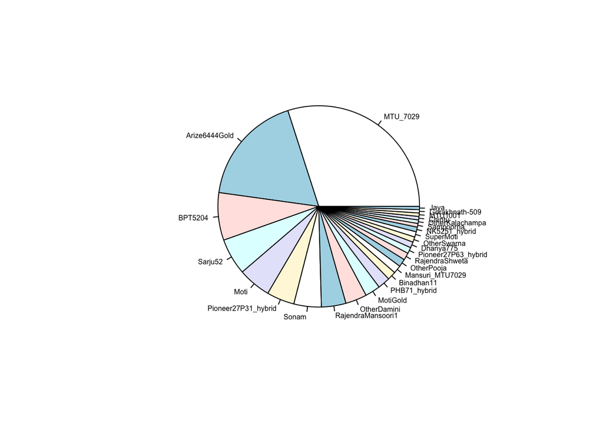

```r
var_name <- data.frame(table(merged_data$varName))
var_name <- var_name %>% arrange(desc(Freq))
err_7029 <- c("MTU_7029", "Mansuri_MTU7029", "MiniMansuri_MTU7029", "MTU7029", "Golden_MTU7029", "MTU7026")
err_pooja <- c("OtherPooja", "OtherPuja")
err_sonam <- c("Sonam", "Swanam")

merged_data$varName <- ifelse(merged_data$varName %in% err_7029, "MTU_7029", merged_data$varName)
merged_data$varName <- ifelse(merged_data$varName %in% err_pooja, "Pooja", merged_data$varName)
merged_data$varName <- ifelse(merged_data$varName %in% err_sonam, "Sonam", merged_data$varName)

dominant_variety <- var_name %>% filter(Freq>30)
merged_data$varName <- ifelse(merged_data$varName %in% dominant_variety$Var1, merged_data$varName, "Other")

pie(dominant_variety$Freq, labels = dominant_variety$Var1, cex = 0.5)
```

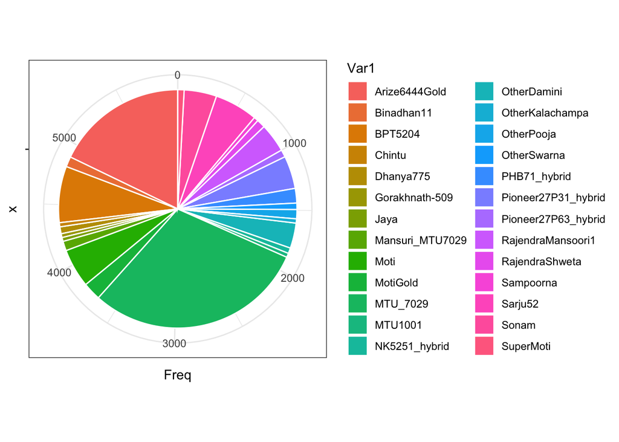

```r
ggplot(dominant_variety, aes(x="", y=Freq, fill=Var1)) +
  geom_bar(stat="identity", width=1, color = "white") +
  coord_polar("y", start=0)+theme_bw()
```

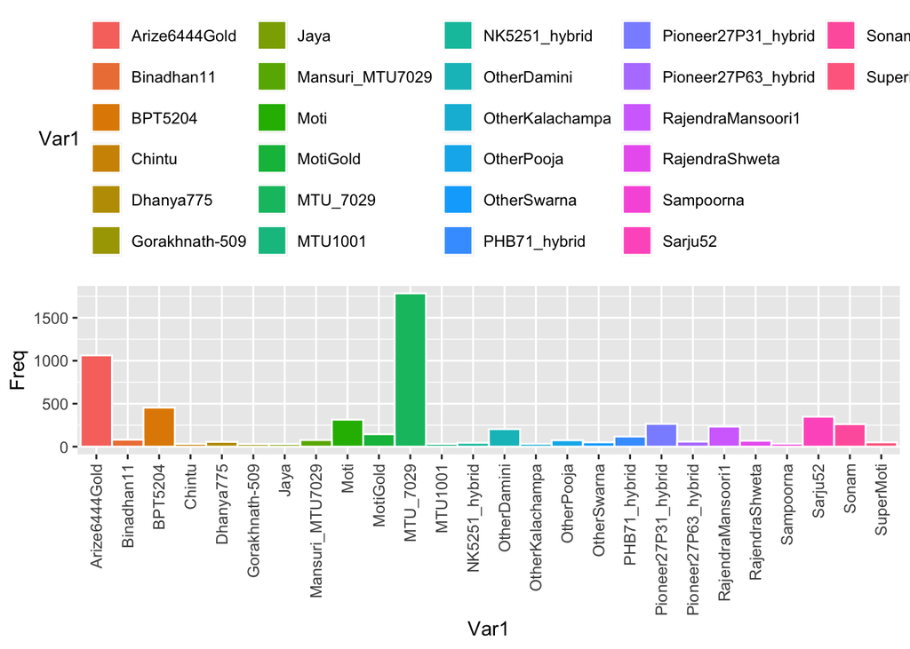

```r
#(https://r-graph-gallery.com/piechart-ggplot2.html)

ggplot(dominant_variety, aes(x=Var1, y=Freq, fill=Var1)) +
  geom_bar(stat = "identity",width=1, color = "white")+theme(axis.text.x = element_text(angle = 90, vjust = 0.5, hjust=1))+theme(legend.position="top")
```

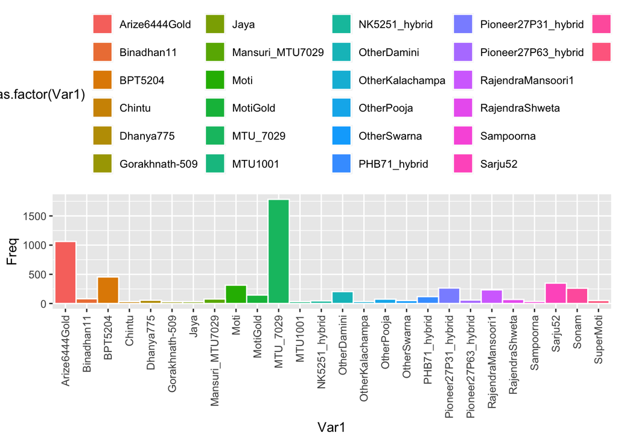

```r
ggplot(dominant_variety, aes(x=Var1, y=Freq)) +
  geom_bar(stat = "identity",width=1, color = "white", aes(fill = as.factor(Var1)))+theme(axis.text.x = element_text(angle = 90, vjust = 0.5, hjust=1))+theme(legend.position="top")#+scale_fill_brewer(palette = "Greens",direction = -1)
```

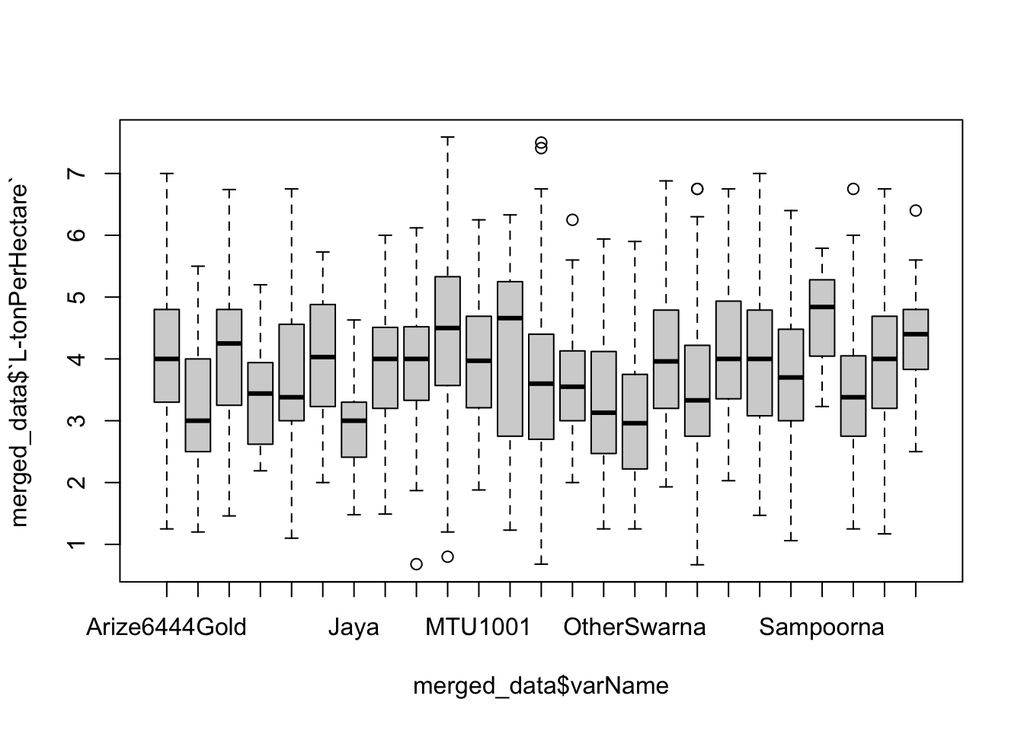

```r
##How yield varies accoridng to variety
boxplot(merged_data$`L-tonPerHectare`~merged_data$varName)
```

# All fertilizer - calculate fert_rates

Now let’s calculate fertilizer rates. For this, we need to calculate the full amount of each fertilizer applied. E.g. total_dap, total_npk. We then need to use the NPK ratings, to calculate the total N, P, and K applies by e.g. calculating n_total (total_npk * n_rating_npk) + (total_urea * n_rating_urea). We then calculate n rate by adjusting for plot size and the land unit size, if local land unit (llu) were used: n_rate = n_total / (plot_size * llu_ha).

```r
library("dplyr")
str(merged_data$basalDAP)
```

```
##  num [1:6831] 28 6 8 50 17 40 100 40 NA NA ...
```

```r
summary(merged_data$basalDAP)
```

```
##    Min. 1st Qu.  Median    Mean 3rd Qu.    Max.    NA's
##    0.00   10.00   20.00   27.85   32.00  500.00    1655
```

```r
merged_data <- merged_data %>%
  mutate(basalDAP = coalesce(basalDAP, 0),
         basalBoron = coalesce(basalBoron, 0),
         basalUrea = coalesce(basalUrea, 0),
         basalNPK = coalesce(basalNPK, 0),
         basalNPKS = coalesce(basalNPKS, 0),
         basalMoP = coalesce(basalMoP, 0),
         basalTSP = coalesce(basalTSP, 0),
         basalSSP = coalesce(basalSSP, 0),
         basalZnSO4 = coalesce(basalZnSO4, 0),
         `1tdDAP`= coalesce(`1tdDAP`, 0),
         `1tdNPK`= coalesce(`1tdNPK`, 0),
         `1tdNPKS`= coalesce(`1tdNPKS`, 0),
         `1tdUrea`= coalesce(`1tdUrea`,0),
         `1tdMoP` = coalesce(`1tdMoP`,0),
         `1tdSSP` = coalesce(`1tdSSP`, 0),
         `1tdTSP` = coalesce(`1tdTSP`,0),
         `1tdZnSO4` = coalesce(`1tdZnSO4`,0),
         `1tdBoron` = coalesce(`1tdBoron`,0),
         `2tdDAP`= coalesce(`2tdDAP`, 0),
         `2tdNPK`= coalesce(`2tdNPK`, 0),
         `2tdNPKS`= coalesce(`2tdNPKS`, 0),
         `2tdUrea`= coalesce(`2tdUrea`,0),
         `2tdMoP` = coalesce(`2tdMoP`,0),
         `2tdSSP` = coalesce(`2tdSSP`, 0),
         `2tdTSP` = coalesce(`2tdTSP`,0),
         `2tdZnSO4` = coalesce(`2tdZnSO4`,0),
         `3tdDAP`= coalesce(`3tdDAP`, 0),
         `3tdNPK`= coalesce(`3tdNPK`, 0),
         `3tdNPKS`= coalesce(`3tdNPKS`, 0),
         `3tdUrea`= coalesce(`3tdUrea`,0),
         `3tdMoP` = coalesce(`3tdMoP`,0),
         `3tdSSP` = coalesce(`3tdSSP`, 0),
         `3tdZnSO4` = coalesce(`3tdZnSO4`,0),
         `3tdBoron` = coalesce(`3tdBoron`,0))
```

# NPK grades

```r
table(merged_data$gradeNPK)
```

```
##
##                            10_26_26          12_32_16          14_35_14
##              6495                 8               199                 5
##          17_17_17      Other0-16-16           Other12           Other14
##                 1                 1                 1                 1
##     Other14_35_14     Other18 18 46     Other18-18-18        Other18.46
##                 1                 1                 1                 1
## Other20 - 20 -013    Other20-20--13     Other20-20-13      Other27-28-0
##                 1                 1                 1                 6
##        Other28-28      Other28-28-0      Other28:28:0        Other28.28
##                 1                81                 6                16
##      Other28.28.0     Other30-45-30
##                 1                 2
```

```r
err_28_28_0 <- c("Other28-28", "Other28-28-0","Other28.28","Other28.28.0","Other28:28:0","Other27-28-0")

merged_data$gradeNPK <- ifelse(merged_data$gradeNPK %in% err_28_28_0, "28_28_0", merged_data$gradeNPK)

err_20_20_13 <- c("Other20-20--13","Other20-20-13","Other20 - 20 -013")

merged_data$gradeNPK <- ifelse(merged_data$gradeNPK %in% err_20_20_13, "20_20_13", merged_data$gradeNPK)

merged_data$gradeNPK <- ifelse(merged_data$gradeNPK == "Other18.46" | merged_data$gradeNPK == "Other18 18 46", "18_18_46", merged_data$gradeNPK)

merged_data$gradeNPK <- ifelse(merged_data$gradeNPK == "Other14_35_14", "14_35_14", merged_data$gradeNPK)

merged_data$gradeNPK = ifelse(merged_data$gradeNPK == "10_26_26" | merged_data$gradeNPK == "12_32_16" | merged_data$gradeNPK == "14_35_14" | merged_data$gradeNPK == "17_17_17"| merged_data$gradeNPK == "18_18_46" | merged_data$gradeNPK == "20_20_13" | merged_data$gradeNPK == "28_28_0", merged_data$gradeNPK, 0)
```

# Separate to NPK grades

```r
cols = c("N_grade", "P_grade", "K_grade")
merged_data <- merged_data %>% separate(gradeNPK, sep = "_", into = cols, remove = FALSE)
merged_data$N_grade = as.numeric(merged_data$N_grade)
merged_data$P_grade = as.numeric(merged_data$P_grade)
merged_data$K_grade = as.numeric(merged_data$K_grade)
summary(is.na(merged_data$N_grade))
```

```
##    Mode   FALSE
## logical    6831
```

# Change all these NA to 0 for further arithmetic

```r
merged_data$N_grade = coalesce(merged_data$N_grade, 0)
merged_data <- merged_data %>% mutate(N_grade = coalesce(N_grade,0),
                                     P_grade = coalesce(P_grade,0),
                                     K_grade = coalesce(K_grade,0))
```

# Calculate N,P,K, rates

This can now get messy - you welcome to make it easier to read. See the second calculation as an example. Always strive for simple code that easy to read :).

A good way to make this easier is by making short calculations across multiple lines.

Also, look out for some style improvements that you can make - e.g. can you identify some assignment operations where we used the equal sign, which works - but is not best practice.

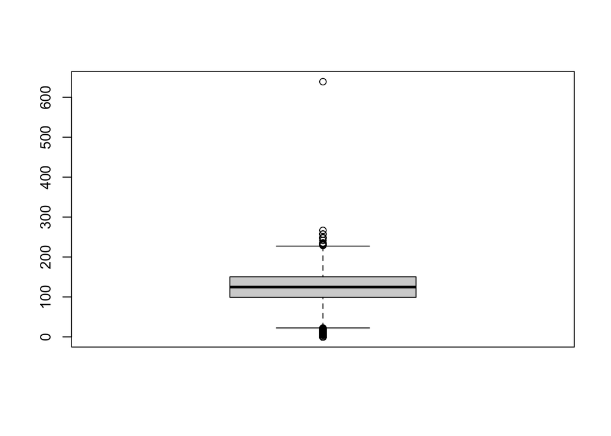

```r
merged_data$total_N <- merged_data$basalDAP * 0.18 + merged_data$basalNPK *
  (merged_data$N_grade / 100) + merged_data$basalUrea * 0.46 + merged_data$`1tdUrea` *
  0.46 + merged_data$`2tdUrea` * 0.46 + merged_data$`3tdUrea` * 0.46 + merged_data$`1tdDAP` *
  0.18 + merged_data$`1tdNPK` * (merged_data$N_grade / 100) + merged_data$`2tdDAP` *
  0.18 + merged_data$`2tdNPK` * (merged_data$N_grade / 100) + merged_data$`3tdDAP` *
  0.18 + merged_data$`3tdNPK` * (merged_data$N_grade / 100)

# try to keep short lines and seperate the code logically.
# td stands for top dressing number 1,2,3.
merged_data$total_p <-
  merged_data$basalDAP * 0.46 +
  merged_data$basalNPK * (merged_data$P_grade /100) +
  merged_data$`1tdDAP` * 0.46 +
  merged_data$`2tdDAP` * 0.46 +
  merged_data$`3tdDAP` * 0.46 +
  merged_data$`1tdNPK` * (merged_data$P_grade / 100) +
  merged_data$`2tdNPK` *  (merged_data$P_grade / 100) +
  merged_data$basalSSP * 0.145 +
  merged_data$basalTSP * 0.45 +
  merged_data$`1tdSSP` * 0.145 +
  merged_data$`2tdSSP` * 0.145 +
  merged_data$`3tdSSP` * 0.145 +
  merged_data$`1tdTSP` * 0.45 +
  merged_data$`2tdTSP` * 0.45

merged_data$total_K = (
  merged_data$basalMoP + merged_data$`1tdMoP` + merged_data$`2tdMoP` + merged_data$`3tdMoP`
) * 0.60 + (
  merged_data$basalNPK  + merged_data$`1tdNPK` + merged_data$`2tdNPK` + merged_data$`3tdNPK`
) * (merged_data$K_grade / 100)

merged_data$total_zn = (
  merged_data$basalZnSO4 + merged_data$`1tdZnSO4` + merged_data$`2tdZnSO4` +
    merged_data$`3tdZnSO4`
) * 0.20

merged_data$total_B  = (merged_data$basalBoron + merged_data$`1tdBoron` + merged_data$`3tdBoron`) *
  0.10

merged_data$total_N_ha = merged_data$total_N / merged_data$cropLarestAreaAcre *
  2.5
#merged_data$total_N_ha = ifelse(merged_data$total_N_ha > 550, NA, merged_data$total_N_ha)
merged_data$total_p_ha = merged_data$total_p / merged_data$cropLarestAreaAcre *
  2.5
merged_data$total_K_ha = merged_data$total_K / merged_data$cropLarestAreaAcre *
  2.5
merged_data$total_Zn_ha = merged_data$total_zn / merged_data$cropLarestAreaAcre *
  2.5
merged_data$total_B_ha = merged_data$total_B / merged_data$cropLarestAreaAcre *
  2.5
merged_data$seed_ha    = merged_data$cropSeedAmt / merged_data$cropLarestAreaAcre *
  2.5

#Corecting the N rates per ha.
boxplot(merged_data$total_N_ha)
k = boxplot(merged_data$total_N_ha)
```

```r
merged_data$total_N_ha = ifelse(merged_data$total_N_ha > 300, 200, merged_data$total_N_ha)
```

# More automatic way..

```r
summary(merged_data$total_N_ha)
```

```
##    Min. 1st Qu.  Median    Mean 3rd Qu.    Max.
##     0.0    98.9   124.8   121.9   150.4   266.7
```

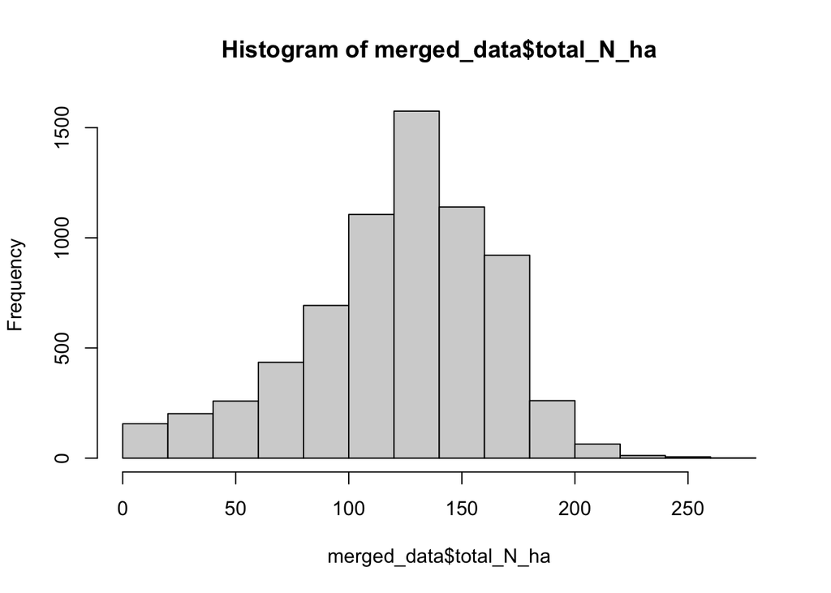

```r
hist(merged_data$total_N_ha)
```

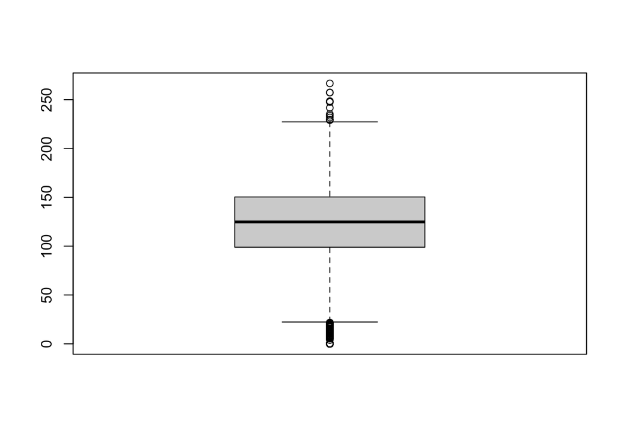

```r
N_err = boxplot(merged_data$total_N_ha)
```

```r
merged_data$total_N_ha  = ifelse(merged_data$total_N_ha>N_err$stats[5,1],N_err$stats[5,1],merged_data$basalDAP)
```

# Summary of N rate by variety types (Aggregate use, multiple category, multiple default function)

```r
mean_N <- aggregate(merged_data[,c("total_N_ha")], list(merged_data$varName), mean, na.rm = TRUE)
min_N <- aggregate(merged_data[,c("total_N_ha")], list(merged_data$varName), min, na.rm = TRUE)
max_N <- aggregate(merged_data[,c("total_N_ha")], list(merged_data$varName), max, na.rm = TRUE)

N_use <- cbind(mean_N, min_N, max_N)
N_use <- N_use[,c(1,2,4,6)]
names(N_use) <- c("Var","Mean_N","Min_N", "Max_N")

aggregate(total_N_ha ~ droughtSeverity+varName, data = merged_data, FUN = function(x)c(mean = mean(x), min = min(x),max = max(x)))
```

```
##    droughtSeverity             varName total_N_ha.mean total_N_ha.min
## 1             High       Arize6444Gold       20.753846       0.000000
## 2              Low       Arize6444Gold       18.799167       0.000000
## 3           Medium       Arize6444Gold       23.437681       0.000000
## 4             None       Arize6444Gold       18.641098       0.000000
## 5              Low          Binadhan11       18.939394       0.000000
## 6           Medium          Binadhan11       23.500000       0.000000
## 7             None          Binadhan11       18.541667      10.000000
## 8             High             BPT5204       30.794872       0.000000
## 9              Low             BPT5204       22.857143       0.000000
## 10          Medium             BPT5204       34.067219       0.000000
## 11            None             BPT5204       28.335145       0.000000
## 12            High              Chintu       30.000000      30.000000
## 13             Low              Chintu       18.000000      18.000000
## 14          Medium              Chintu       22.000000       0.000000
```

[output cut: 183 more lines]

```r
aggregate(total_N_ha ~ droughtSeverity+varName, data = merged_data, FUN = function(x)c(mean = mean(x), min = min(x),max = max(x)))
```

```
##    droughtSeverity             varName total_N_ha.mean total_N_ha.min
## 1             High       Arize6444Gold       20.753846       0.000000
## 2              Low       Arize6444Gold       18.799167       0.000000
## 3           Medium       Arize6444Gold       23.437681       0.000000
## 4             None       Arize6444Gold       18.641098       0.000000
## 5              Low          Binadhan11       18.939394       0.000000
## 6           Medium          Binadhan11       23.500000       0.000000
## 7             None          Binadhan11       18.541667      10.000000
## 8             High             BPT5204       30.794872       0.000000
## 9              Low             BPT5204       22.857143       0.000000
## 10          Medium             BPT5204       34.067219       0.000000
## 11            None             BPT5204       28.335145       0.000000
## 12            High              Chintu       30.000000      30.000000
## 13             Low              Chintu       18.000000      18.000000
## 14          Medium              Chintu       22.000000       0.000000
```

[output cut: 183 more lines]

# Dealing with Dates (Pattern matching, replacements, Date format, Julian days converison)

R can handle data with it’s own class. For this we use the as.Date() function. There is a global standard for defining dates strptime -> String (i.e. letters, words, not numbers) representation of time. What is in R a character vector, is often called a string in other programming languages.

So when you convert a character vector to a Date - then you can use this format it represent typical data components with % and letters. E.g. **%Y** is The Year including century. So a date with “1998-05-30” would be “%Y-%m-%d”. If we use e.g. month name like “1998-May-30” then it would be “%Y-%b-%d”.

The date format holds dates as number of days since a defined starting date. Often that is “1980-01-01”.

A lot of times - we want to just calculate number of days - and thus use day of year for dates. However, if e.g. a season stretched across two calendar years then it can cause issues. So be careful on how you use and define dates.

The lubridate package holds many convenience functions for working with dates. For example the yday() function calculates the day of year for us.

For cleaning - we basically want to bring the columns into the ISO standard “yyyy-mm-dd”. In this format - it can easily be read and covnerted as this is the accepted standard. If our data does not have that format, we can convert it to this format using R through the above mentioned methods.

```r
library(lubridate)
merged_data$harvestDate1 = merged_data$harvestDate

merged_data$harvestDate1 = gsub( "/", "-", merged_data$harvestDate1, ignore.case = T)
merged_data$harvestDate1 = gsub("-12-2018", "-12-2017",merged_data$harvestDate1, ignore.case = T)
table(merged_data$harvestDate1)
```

```
##
## 01-01-2018 01-09-2017 01-11-2017 01-12-2017 02-01-2018 02-10-2017 02-11-2017
##          1          1         61         59          7          1        112
## 02-12-2017 03-01-2018 03-09-2017 03-10-2017 03-11-2017 03-12-2017 04-01-2018
##         76          2          1          3        130         32          2
## 04-10-2017 04-11-2017 04-12-2017 05-01-2018 05-08-2017 05-09-2017 05-10-2017
##          6        116         47          2          1          1          2
## 05-11-2017 05-12-2017 06-01-2018 06-09-2017 06-11-2017 06-12-2017 07-09-2017
##        203        124          1          1        119         40          1
## 07-10-2017 07-11-2017 07-12-2017 08-01-2018 08-08-2017 08-10-2017 08-11-2017
##          4        145         23          1          1          1        181
## 08-12-2017 09-10-2017 09-11-2017 09-12-2017 10-01-2018 10-08-2017 10-09-2017
##         43          9        123         19          2          3          1
## 10-10-2017 10-11-2017 10-12-2017 11-10-2017 11-11-2017 11-12-2017 12-09-2017
##          7        402         75         15        129         20          1
## 12-10-2017 12-11-2017 12-12-2017 13-10-2017 13-11-2017 13-12-2017 14-10-2017
##          6        166         44         10        104         23         17
## 14-11-2017 14-12-2017 15-01-2018 15-08-2017 15-10-2017 15-11-2017 15-12-2017
##        122         24          1          1         24        353         54
## 16-01-2018 16-10-2017 16-11-2017 16-12-2017 17-01-2018 17-09-2017 17-10-2017
##          2         10        139          9          1          2         18
## 17-11-2017 17-12-2017 18-08-2017 18-10-2017 18-11-2017 18-12-2017 19-08-2017
##        108          8          1         41        150         14          1
## 19-10-2017 19-11-2017 19-12-2017 20-08-2017 20-10-2017 20-11-2017 20-12-2017
##         42         53         12          3         98        300         55
## 21-08-2017 21-10-2017 21-11-2017 21-12-2017 22-04-2017 22-08-2017 22-10-2017
##          1         36         69          9          1          3         35
## 22-11-2017 22-12-2017 23-08-2017 23-10-2017 23-11-2017 23-12-2017 24-08-2017
##        156         19          1         27        119          8          1
## 24-10-2017 24-11-2017 24-12-2017 25-08-2017 25-10-2017 25-11-2017 25-12-2017
##         55        106          5          2        157        286         12
## 26-10-2017 26-11-2017 26-12-2017 27-10-2017 27-11-2017 27-12-2017 28-10-2017
##         73         65          8         93         62          8        108
## 28-11-2017 28-12-2017 29-09-2017 29-10-2017 29-11-2017 29-12-2017 30-08-2017
##        153         17          1         58        101          7          5
## 30-10-2017 30-11-2017 30-12-2017 31-08-2018 31-10-2017 31-12-2017
##        185        311          9          1         78          7
```

```r
str(merged_data$harvestDate1)
```

```
##  chr [1:6831] "28-10-2017" "13-11-2017" "02-11-2017" "27-10-2017" ...
```

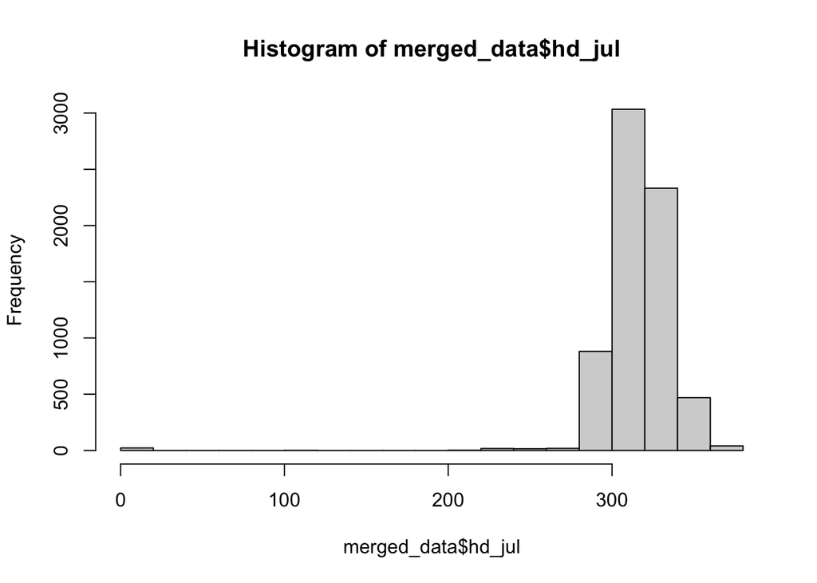

```r
merged_data$harvestDate1 = as.Date(merged_data$harvestDate1, format = "%d-%m-%Y")

#Convert to Julian Days
merged_data$hd_jul <- as.POSIXlt(merged_data$harvestDate1)$yday
hist(merged_data$hd_jul)
```

```r
merged_data$hd_jul <- ifelse(merged_data$hd_jul < 35, merged_data$hd_jul + 365, merged_data$hd_jul)


merged_data$seedingSowingTransDate1 <- merged_data$seedingSowingTransDate

table(merged_data$seedingSowingTransDate1)
```

```
##
## 01/06/2017 01/07/2017 01/08/2017 02/06/2017 02/07/2017 02/08/2017 03/07/2017
##          6        157         36          6        139         67        158
## 03/08/2017 04/06/2017 04/07/2017 04/08/2017 05/05/2017 05/06/2017 05/07/2017
##         20          5        147         24          1         12        268
## 05/08/2017 06/06/2017 06/07/2017 06/08/2017 07/06/2017 07/07/2017 07/08/2017
##         37         17        168         11         16        138          5
## 08/06/2017 08/07/2017 08/08/2017 09/06/2017 09/07/2017 09/08/2017 10/06/2017
##         27        198         16         13         97         16         35
## 10/07/2017 10/08/2017 11/06/2017 11/07/2017 11/08/2017 12/06/2017 12/07/2017
##        482         42         10        200          6         13        261
## 12/08/2017 13-06-2017 13-07-2017 13-08-2017 14-06-2017 14-07-2017 14-08-2017
##         10         10        205          8         17        168          9
## 15-05-2017 15-06-2017 15-07-2017 15-08-2017 15-09-2017 16-05-2017 16-06-2017
##          1         27        352         32          1          1         12
## 16-07-2017 16-08-2017 17-05-2017 17-06-2017 17-07-2017 17-08-2017 18-05-2017
##        114          8          1         13        103          8          1
## 18-06-2017 18-07-2017 18-08-2017 19-05-2017 19-06-2017 19-07-2017 19-08-2017
##         21        173          8          1         11        130          2
## 19-12-2017 20-05-2017 20-06-2017 20-07-2017 20-08-2017 21-06-2017 21-07-2017
##          1          1         84        386          8         81        123
## 21-08-2017 22-06-2017 22-07-2017 22-08-2017 23-06-2017 23-07-2017 23-08-2017
##          2        101        187          4         76         74          2
## 24-06-2017 24-07-2017 24-08-2017 25-05-2017 25-06-2017 25-07-2017 25-08-2017
##         67         81          3          1         71        202          5
## 26-05-2017 26-06-2017 26-07-2017 26-08-2017 27-05-2017 27-06-2017 27-07-2017
##          3         61         80          2          1         42         78
## 27-08-2017 28-05-2017 28-06-2017 28-07-2017 28-08-2017 29-05-2017 29-06-2017
##          1          1         95        114          5          2        103
## 29-07-2017 29-08-2017 30-05-2017 30-06-2017 30-07-2017 30-08-2017 31-05-2017
##         57          1          6        138        119          5          1
## 31-07-2017 31-08-2017
##         54          1
```

```r
merged_data$seedingSowingTransDate1 <- gsub( "/", "-", merged_data$seedingSowingTransDate1, ignore.case = T)
str(merged_data$seedingSowingTransDate1)
```

```
##  chr [1:6831] "20-07-2017" "17-07-2017" "11-07-2017" "29-06-2017" ...
```

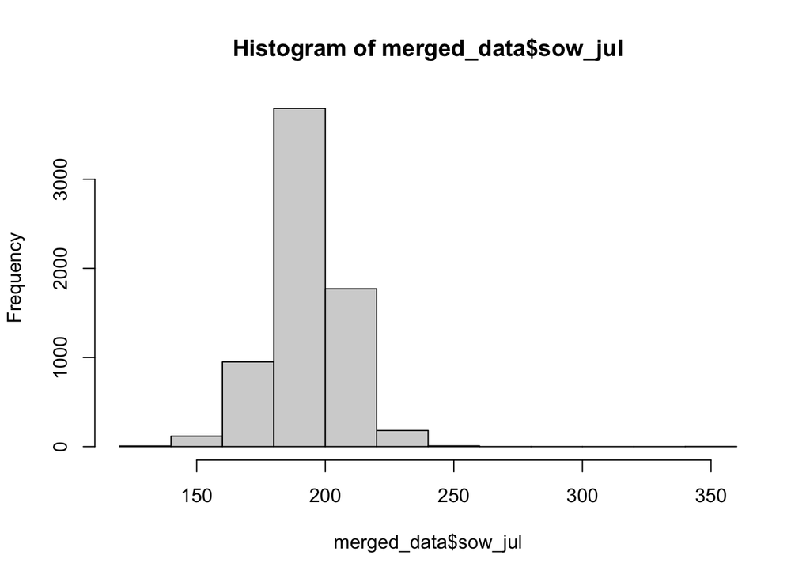

```r
merged_data$seedingSowingTransDate1 <- as.Date(merged_data$seedingSowingTransDate1, format = "%d-%m-%Y")

merged_data$sow_jul1 <- as.POSIXlt(merged_data$seedingSowingTransDate1)$yday

merged_data$sow_jul  <- yday(as.Date(merged_data$seedingSowingTransDate1,"%d-%m-%Y"))

hist(merged_data$sow_jul)
```

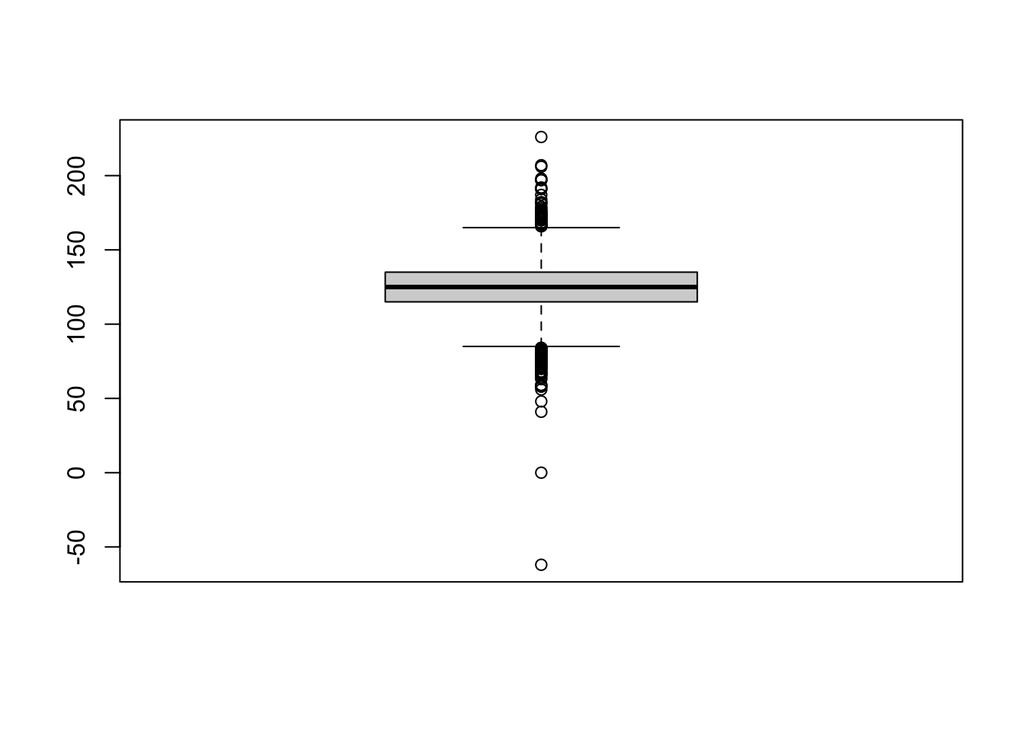

```r
merged_data$dur <- merged_data$hd_jul - merged_data$sow_jul

boxplot(merged_data$dur)
```

```r
merged_data$dur <- ifelse(merged_data$dur < 50, mean(merged_data$dur,na.rm = T), merged_data$dur)

which(merged_data$dur < 80)
```

```
##  [1]  400  523 1021 1064 1121 1136 1320 1421 1455 1592 1657 1694 2038 2244 2480
## [16] 2648 2732 2876 2951 3281 3316 3401 3725 3885 4040 4271 4380 4531 5214 5609
## [31] 5698 5771 5851 5962 6029 6125 6133 6177 6463
```

#Subset based on some condition for particular variable

```r
table(merged_data$varType)
```

```
##
##  Basmati   Hybrid Improved    Local  Unknown
##       24     1791     4878      137        1
```

```r
# Subset for non basmati and Unknown
merged_data1 = merged_data %>% dplyr::filter( varType %in% c("Hybrid","Improved","Local"))

merged_data2 = subset(merged_data, varType == "Hybrid" | varType == "Improved" | varType == "Local")
```

# Subset some of the variables

```r
merged_data3 = subset(merged_data, select=c("varType","total_N_ha"))
merged_data3 = subset(merged_data, select = collectionDate:state)

merged_data3 = merged_data[,grep("Urea",colnames(merged_data))]
merged_data3 = merged_data[,grep("Urea|DAP",colnames(merged_data))]

vect = c("Urea","DAP","NPK")
merged_data3 = merged_data[,grep(paste0(vect, collapse = "|", sep = ""), colnames(merged_data))]
```

# Changing some features

Sometimes, we have many categories and do not want to use them all in our analysis. For example, we find that there are only vary few cases of a specific class - in that case we can change that value. There are many ways to do it. Ifelse, is a common way to evaluate and replace. You can also use subsetting.

```r
table(merged_data$drainClass)
```

```
##
##     LowLand  MediumLand      Upland VeryLowLand
##         845        5136         819          31
```

```r
merged_data$drainClass <- ifelse(merged_data$drainClass == "VeryLowLand", "LowLand", merged_data$drainClass)
#below we use subsetting, by first selecting the drainClass variable,
#then identifying the indexes where drainage class is VeryLowLand and
#assigning the value LowLand to all the selected values

merged_data$drainClass[merged_data$drainClass == "VeryLowLand"] <- "LowLand"


table(merged_data$cropResiduePcnt)
```

```
##
##    0    5   10   15   20   40   60   80  100
## 1225 3699  727    1  134  208   31   34   50
```

```r
str(merged_data$cropResiduePcnt)
```

```
##  int [1:6831] 5 5 5 10 5 5 5 0 5 0 ...
```

```r
merged_data$cropResiduePcnt <- as.numeric(merged_data$cropResiduePcnt)
merged_data$residu_retain <- ifelse(merged_data$cropResiduePcnt == 0, "No", "Yes")


#table(data$prevCrop)
#data$prevCrop    <- ifelse(data$prevCrop == "Wheat" | data$prevCrop == "Fallow", data$prevCrop, "Other")
```